# Parametized Data Germany

To prove my skills in the producing parametized .Rmd’s, I’ve used an online COVID-19 dataset and parametized the visualisation of this data file. For this parameterization, the country of the data, the year of the data and the months which the data covers have been added as variables.

For this page, the params have been set too:

- Country: Germany (Only shows data from the Germany)
- Year: 2020, 2021, 2022 (Shows data from 2020, 2021, 2022)
- Month: 1, 2, 3, 4, 5, 6, 7, 8, 9, 10, 11, 12 (Shows data from months number 1, 2, 3, 4, 5, 6, 7, 8, 9, 10, 11, 12)

In order to showcase this, this process has been repeated for 3 sets of parameters

click here for a page of data about Belgium

click here for a page about data in Norway

```r
# Parameters have been manually set for the purpose of this site, as bookdown does not support stating parameters in YAML
params$country<-"Germany"
params$year<-c(2020:2022)
params$month<-c(1:12)
```

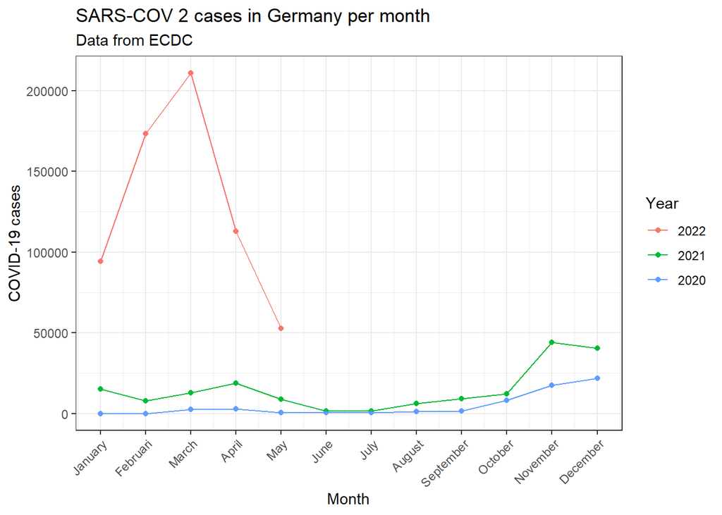

```r
############################################################### Reading data
covid_data<-read.csv("./data.raw/data.csv")
covid_data_vis<-covid_data

############################################################### Mangling data
covid_years<-covid_data$year %>% unique()
covid_data_vis$year<-factor(as.character(covid_data$year), levels = as.character(covid_years)) #Making year a factor so it colours nicely instead of using a gradiant

months<-c("January", "Februari", "March", "April", "May", "June", "July", "August", "September", "October", "November", "December") #Storing months to plaster on x-axis

covid_data_vis_filter1<-covid_data_vis %>% filter(year %in% params$year,
                          month %in% params$month,
                          countriesAndTerritories %in% params$country)

############################################################### Creating visualisation: Cases per month
covid_data_vis_filter1 %>% group_by(month, year) %>% summarise(
  cases=mean(cases, na.rm=TRUE)
) %>% ggplot(aes(x=month, y=cases))+
  geom_point(aes(color=year))+
  geom_line(aes(group=year, color=year))+
  theme_bw()+
  theme(axis.text.x = element_text(angle=45, hjust=1))+
  labs(
    title=paste0("SARS-COV 2 cases in ",params$country, " per month"),
    subtitle = "Data from ECDC",
    x="Month",
    y="COVID-19 cases",
    color="Year"
  )+
  scale_x_continuous(breaks=(seq(1:12)), labels = months)
```

[figure not shown]

```r
############################################################# Creating visualisation: Deaths per month
covid_data_vis_filter1 %>% group_by(month, year) %>% summarise(
  deaths=mean(deaths, na.rm=TRUE)
) %>% ggplot(aes(x=month, y=deaths))+
  geom_point(aes(color=year))+
  geom_line(aes(group=year, color=year))+
  theme_bw()+
  theme(axis.text.x = element_text(angle=45, hjust=1))+
  labs(
    title=paste0("SARS-COV 2 deaths in ",params$country, " per month in ", params$year),
    subtitle = "Data from ECDC",
    x="Month",
    y="COVID-19 deaths",
    color="Year"
  )+
  scale_x_continuous(breaks=(seq(1:12)), labels = months)
```